# Analysis of NCT Data

Deepak Kumar Yuvanesan

13 November, 2020

### Introduction

##### This document seeks to perform an exploratory dive into a Road Safety data which informs on operations of the National Car Testing Service (“NCTS”) recorded for Road Safety Authority(“RSA”) Ireland, from the years 2015-2018. The analysis presented herein are based on provided inputs from Applus Car Testing Service Ltd. (ACTS) and the Automobile Association (AA).This focuses on statistics in relation to the NCT (National Car Test) including annual pass/fail rates,make and model data of the respective years.The raw data was extracted from https://www.rsa.ie/RSA/Your-Vehicle/Your-Vehicle-/NCT-Statistics-/ , Pass/Fail rates by Centre , Make and Model Data CSV files were downloaded for data manipulation and visualization workouts.

**Top 25 Car Makers with highest pass% cumulative for 2015-2018**

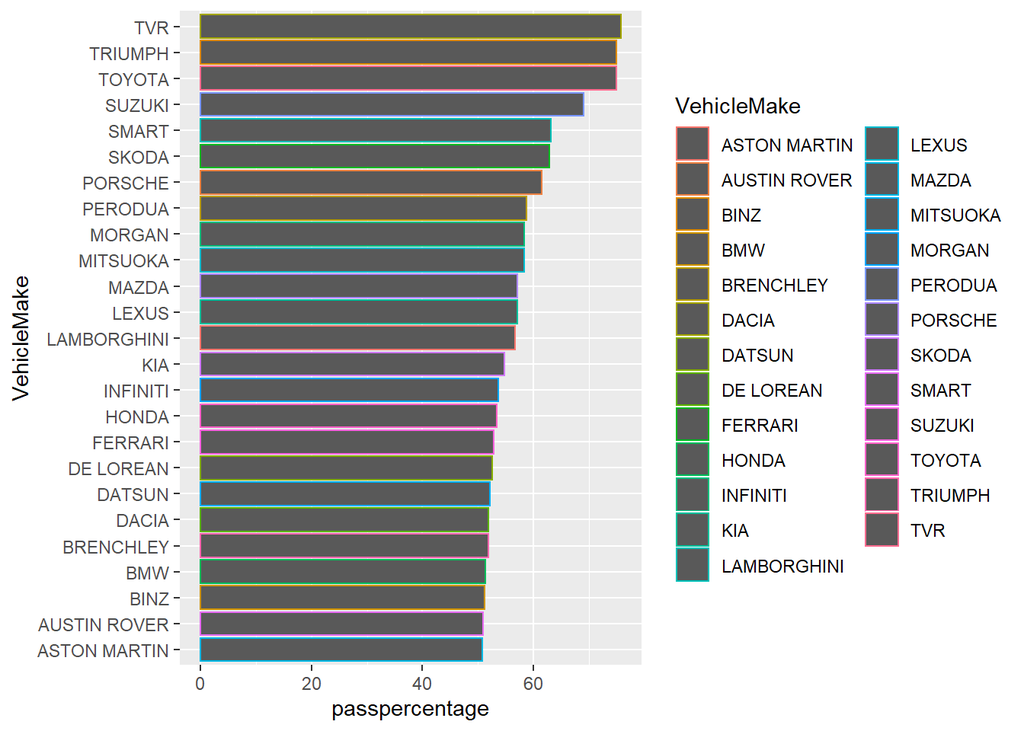

*Insights:*

##### TVR, Triumph and Toyota have the highest Pass percentages for all the four years together, and gives us the initial impressions that they are very reliable.

**———————————————————————————————————————————————————————————————–**

### Analysis by Car Makes/Test Centres

**Top 10 Car makers with pass% per year (Min Criteria: Atleast 10 tests)**

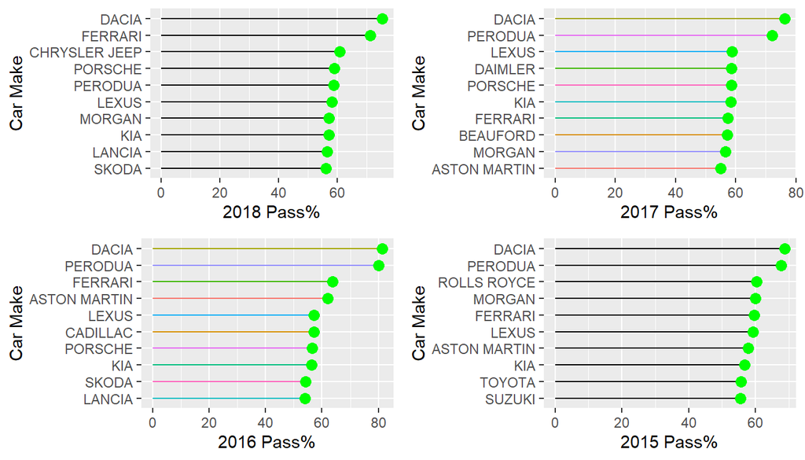

*Insights:* Dacia seems to be the best with maximum number of tests passed across the years, with Perodua acquiring the second position in terms of pass rates across the years, except for the year 2018.

**———————————————————————————————————————————————————————————————–**

**Top 10 Car makers with fail% per year (Min criteria: Atleast 10 tests)**

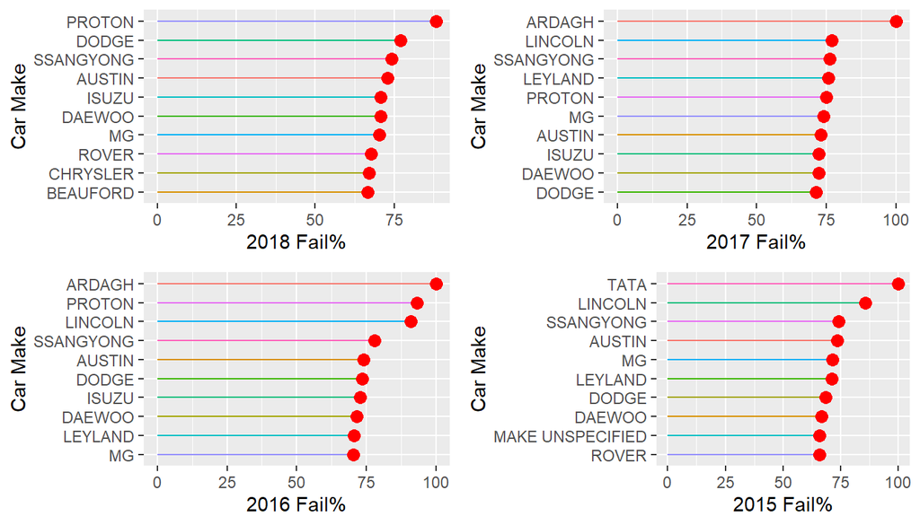

*Insights:* Proton seems to have maximum fail rate for the year 2018. Ardagh had the highest fail rate for two consecutive years i.e. 2016 and 2017 and Tata had the maximum fail rate for the year 2015.

**———————————————————————————————————————————————————————————————–**

**Makers with high Pass% common to all four years among the top 10**

```
## # A tibble: 5 x 4
##   VehicleMake   Tot  Pass Passpercentage
##   <chr>       <int> <int>          <dbl>
## 1 DACIA        4885  3702           75.8
## 2 FERRARI       191   120           62.8
## 3 KIA         79654 45525           57.2
## 4 LEXUS       27300 15916           58.3
## 5 PERODUA       243   168           69.1
```

[interactive chart not shown]

*Insights:* Dacia still tops the pass test rates for all the four years, followed by Perodua. At the fifth place we can notice Kia to be nearly constant with the pass rates for a period of four years.

**Makers with high Fail% common to all four years among the top 10**

```
## # A tibble: 5 x 4
##   VehicleMake   Tot  fail Failpercentage
##   <chr>       <int> <int>          <dbl>
## 1 AUSTIN       1148   843           73.4
## 2 DAEWOO      10840  7560           69.7
## 3 DODGE         792   574           72.5
## 4 MG           1708  1220           71.4
## 5 SSANGYONG    2741  2075           75.7
```

[interactive chart not shown]

**———————————————————————————————————————————————————————————————–**

*Now that we have made a good analysis of pass/fail rates, a deeper dive into the analysis, will answer us as to why the car makes failed the test with a high failure percentage. To highlight the cause of failure, we plotted a bar plot displaying the failure reason for the top 5 car makes with high fail rate for each year.*

[interactive chart not shown]

```
##    VehicleMake year Total Fail
## 1       AUSTIN 2018   248  181
## 6       AUSTIN 2017   281  205
## 11      AUSTIN 2016   274  203
## 16      AUSTIN 2015   345  254
```

```
##    VehicleMake year Total Fail
## 2       DAEWOO 2018  1257  889
## 7       DAEWOO 2017  2102 1519
## 12      DAEWOO 2016  3178 2276
## 17      DAEWOO 2015  4303 2876
```

```
##    VehicleMake year Total Fail
## 3        DODGE 2018   188  145
## 8        DODGE 2017   210  150
## 13       DODGE 2016   185  136
## 18       DODGE 2015   209  143
```

```
##    VehicleMake year Total Fail
## 4           MG 2018   236  166
## 9           MG 2017   357  264
## 14          MG 2016   494  347
## 19          MG 2015   621  443
```

```
##    VehicleMake year Total Fail
## 5    SSANGYONG 2018   618  459
## 10   SSANGYONG 2017   673  514
## 15   SSANGYONG 2016   693  540
## 20   SSANGYONG 2015   757  562
```

*Insights:* When we hover over the bar plot, we see that the main reason why Austin Car Make failed the tests were because of Vehicle and Safety equipment with a high failure value. Daewoo Car make had a constant reason for failure which was the brake test for all the four years. Dodge has two reasons as to why it failed one being the steering and suspension and lighting and electrical. MG and SsangYong being at the top 5 failed with a common reason i.e Lighting and Electrical across all the four years.

*Yearwise Analysis of Pass Rate by Test Centres*

[interactive chart not shown]

*Insights:* The Yearwise trend of Pass rates for each test centre shows the Top 10 results between 2015 and 2018. The trend for Abbeyfeale shows a gradual increase in Pass% between 2015 and 2017, with a slight drop between 2017 and 2018. We can see that the pass rate in Killarney has consistently dropped every year, from 68.1% in 2015 to 66.4% in 2018. The test centre in Tralee experienced a significant drop in pass rate from 67.8% to 65.4% between 2015 and 2016, before stabilising in the remaining years.

**———————————————————————————————————————————————————————————————–**

A further deep dive analysis into the dataset throws some light that most makers fail mostly due to specific reasons: Austin fails as it does not comply with Vehicle and Safety equipment most of the time. Daewoo fails brake test more than often, Dodge, MG and Ssangyong fail Lighting and Electrical tests, owing to its high failure rates for the four years. If the above reasons can be rectified, then the there are high chances that these car makers can improve their test scores going forward. Finally, we plot the Pass/Fail rates by Test centres and observe that, the tests in Kilkenny has got high consistent pass rates, and also that Killarney has been dropping in its pass rates. In addition to the analysis made, if we consider year of car make and conduct hypothesis testing between the age of car make versus failure rates, it might help us reduce and understand how the age affects the safety of the car. All the above analysis provided from the given datasets can be helpful for car makers to improve the safety equipment of the car for future models.